# Phuong’s study

## Data package

Here you’ll need a number of data that I have developped for vietnam. To install them, you need the package `remote` installed on your system:

```r
> install.packages("remote")
```

Then install the following packages:

```r
> remotes::install_github("epix-project/gdpm")
> remotes::install_github("epix-project/gadmVN")
> remotes::install_github("epix-project/gso")
```

## Surveillance data

Surveillance data from [GDPM](http://vncdc.gov.vn/en) are in the following package:

```r
> library(gdpm)
```

To see the list of diseases that are available in the package:

```r
> diseases
          disease       from         to
1      adenovirus 1980-01-01 2017-12-31
2      amoebiasis 1980-01-01 2017-12-31
3         anthrax 1990-01-01 2017-12-31
4      chickenpox 1980-01-01 2017-12-31
5         cholera 1980-01-01 2017-12-31
6          dengue 1980-01-01 2017-12-31
7        diarrhea 1980-01-01 2017-12-31
8       diphteria 1980-01-01 2017-12-31
9      dysenteria 1980-01-01 2010-12-31
10   encephalitis 1980-01-01 2017-12-31
11           h5n1 2004-01-01 2017-12-31
12      hepatitis 1980-01-01 2017-12-31
13           hfmd 2011-01-01 2017-12-31
14            ili 1980-01-01 2017-12-31
15 leptospiriosis 1986-01-01 2017-12-31
16        malaria 2003-01-01 2017-12-31
17        measles 1980-01-01 2017-12-31
18     meningitis 1980-01-01 2017-12-31
19          mumps 1980-01-01 2017-12-31
20      nntetanus 1990-01-01 2017-12-31
21      pertussis 1980-01-01 2017-12-31
22         plague 1980-01-01 2017-12-31
23          polio 1980-01-01 2017-12-31
24         rabies 1980-01-01 2017-12-31
25        rubella 2006-01-01 2017-12-31
26       shigella 1980-01-01 2017-12-31
27          ssuis 2011-01-01 2017-12-31
28        tetanus 1980-01-01 2017-12-31
29        typhoid 1980-01-01 2017-12-31
```

If you want hepatitis:

```r
> hepatitis <- getid(hepatitis)
```

which gives:

```r
> head(hepatitis)
     province    month year incidence_hepatitis mortality_hepatitis
5293 An Giang  January 1980                  NA                  NA
5297 An Giang February 1980                  NA                  NA
5298 An Giang    March 1980                  NA                  NA
5299 An Giang    April 1980                  NA                  NA
5300 An Giang      May 1980                  NA                  NA
5301 An Giang     June 1980                  NA                  NA
```

You can see the time range:

```r
> range(hepatitis$year)
[1] 1980 2017
```

You can also see the number of provinces:

```r
> length(unique(hepatitis$province))
[1] 39
```

39 is the number of provinces that existed in Vietnam in 1980. These provinces have split since then to reach a number of 63 in 2008. For consistency, we always use the provinces’ definition of the earlier time in the data. For example, if you are interested in the hepatitis data since 2008 instead of 1980:

```r
> hepatitis2 <- getid(hepatitis, from = 2008)
```

You can see that, for this time range:

```r
> range(hepatitis2$year)
[1] 2008 2017
```

you know have the 63 provinces that you could expect:

```r
> length(unique(hepatitis2$province))
[1] 63
```

## Maps of Vietnamese provinces

For handling maps in R, you need the following package:

```r
> library(sf)
Linking to GEOS 3.6.1, GDAL 2.1.3, PROJ 4.9.3
```

Maps for Vietnam from [GADM](https://gadm.org) are in the following package:

```r
> library(gadmVN)
```

The retrieval of maps here follows the same principle as for the surveillance data: depending on the date you want, you’ll get different maps. For example, if you want the map of the provinces of Vietnam in 1980:

```r
> vietnam1980 <- gadm(1980, "provinces")
```

which gives:

```r
> vietnam1980
Simple feature collection with 40 features and 1 field
geometry type:  MULTIPOLYGON
dimension:      XY
bbox:           xmin: 102.1452 ymin: 8.563332 xmax: 109.4612 ymax: 23.38276
epsg (SRID):    4326
proj4string:    +proj=longlat +datum=WGS84 +no_defs
First 10 features:
            province                       geometry
2           An Giang MULTIPOLYGON (((105.1169 10...
37 Ba Ria - Vung Tau MULTIPOLYGON (((107.0719 10...
26          Bac Thai MULTIPOLYGON (((106.0978 21...
4            Ben Tre MULTIPOLYGON (((106.4035 10...
46    Binh Tri Thien MULTIPOLYGON (((107.3872 16...
27          Cao Bang MULTIPOLYGON (((105.5675 23...
12          Cuu Long MULTIPOLYGON (((106.2893 10...
60          Dack Lak MULTIPOLYGON (((108.1125 12...
36          Dong Nai MULTIPOLYGON (((107.3695 11...
1          Dong Thap MULTIPOLYGON (((105.4328 10...
```

which is basically a data frame here with one column containing the provinces’ name and another containing the coordinates of the polygons. You can see by the way that there are 40 provinces. You can plot it:

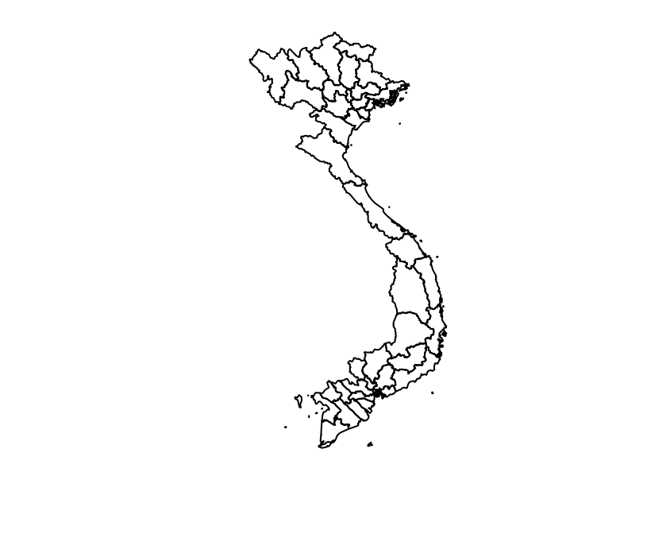

```r
> plot(st_geometry(vietnam1980))
```

If, on the contrary, you are intereste in the map of the provinces as they are today, just use the default values:

```r
> vietnam <- gadm()
```

which gives 63 polygons:

```r
> vietnam
Simple feature collection with 63 features and 4 fields
geometry type:  MULTIPOLYGON
dimension:      XY
bbox:           xmin: 102.145 ymin: 8.421878 xmax: 109.46 ymax: 23.39217
epsg (SRID):    4326
proj4string:    +proj=longlat +datum=WGS84 +no_defs
First 10 features:
            province              region               region_economic                     mics_region                       geometry
1           An Giang        Mekong Delta                  Mekong Delta              Mekong River Delta MULTIPOLYGON (((105.3745 10...
2  Ba Ria - Vung Tau           Southeast                     Southeast                       Southeast MULTIPOLYGON (((107.0914 10...
3          Bac Giang           Northeast Northern Midlands & Mountains Northern Midlands and Mountains MULTIPOLYGON (((105.9644 21...
4            Bac Kan           Northeast Northern Midlands & Mountains Northern Midlands and Mountains MULTIPOLYGON (((105.5904 22...
5           Bac Lieu        Mekong Delta                  Mekong Delta              Mekong River Delta MULTIPOLYGON (((105.4164 9....
6           Bac Ninh     Red River Delta               Red River Delta                 Red River Delta MULTIPOLYGON (((106.0285 20...
7            Ben Tre        Mekong Delta                  Mekong Delta              Mekong River Delta MULTIPOLYGON (((106.6355 9....
8          Binh Dinh South Central Coast                 Central Coast   North and South Central Coast MULTIPOLYGON (((109.24 13.7...
9         Binh Duong           Southeast                     Southeast                       Southeast MULTIPOLYGON (((106.7618 10...
10        Binh Phuoc           Southeast                     Southeast                       Southeast MULTIPOLYGON (((106.9003 11...
```

Note that, compared to the `vietnam1980` data frame, we have here additional information. As before, we can plot the polygons of the data:

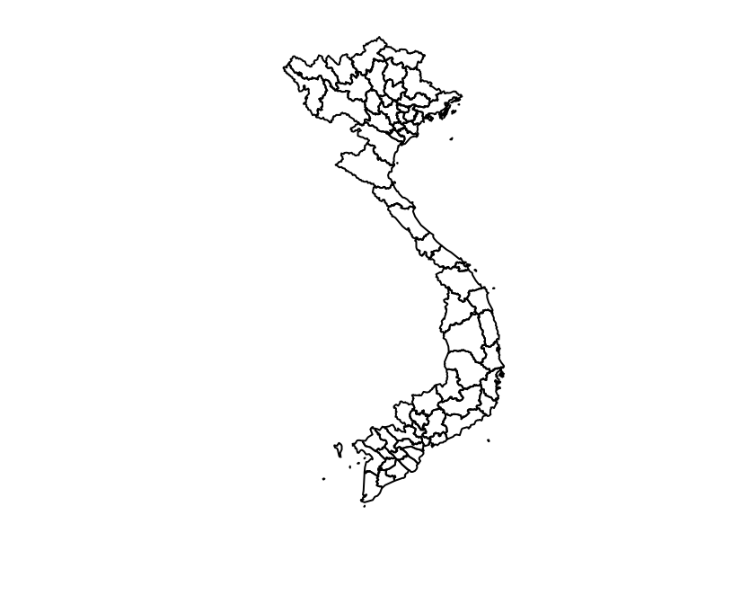

```r
> plot(st_geometry(vietnam))
```

## Mapping a variable

Let’s say now that you want to map the incidence in January 2008. First, you need to retrieve these values. For that, let’s use this package:

```r
> library(dplyr)

Attaching package: 'dplyr'
The following objects are masked from 'package:stats':

    filter, lag
The following objects are masked from 'package:base':

    intersect, setdiff, setequal, union
```

And then:

```r
> hep <- hepatitis2 %>%
+   filter(month == "January", year == 2008) %>%
+   select(province, incidence_hepatitis)
```

which gives:

```r
> hep
            province incidence_hepatitis
1           An Giang                   1
2  Ba Ria - Vung Tau                  65
3          Bac Giang                   1
4            Bac Kan                   0
5           Bac Lieu                   3
6           Bac Ninh                   9
7            Ben Tre                   4
8          Binh Dinh                   1
9         Binh Duong                  12
10        Binh Phuoc                  14
11        Binh Thuan                   0
12            Ca Mau                   5
13           Can Tho                   3
14          Cao Bang                  18
15           Da Nang                   3
16           Dak Lak                   8
17          Dak Nong                   0
18         Dien Bien                   7
19          Dong Nai                   1
20         Dong Thap                   8
21           Gia Lai                   0
22          Ha Giang                   2
23            Ha Nam                   2
24            Ha Noi                  40
25           Ha Tinh                   0
26         Hai Duong                  10
27         Hai Phong                  11
28         Hau Giang                   0
29       Ho Chi Minh                   8
30          Hoa Binh                   0
31          Hung Yen                   0
32         Khanh Hoa                  13
33        Kien Giang                  27
34           Kon Tum                   3
35          Lai Chau                  15
36          Lam Dong                  11
37          Lang Son                   6
38           Lao Cai                  27
39           Long An                  14
40          Nam Dinh                   1
41           Nghe An                   7
42         Ninh Binh                   2
43        Ninh Thuan                   6
44           Phu Tho                   1
45           Phu Yen                   0
46        Quang Binh                  11
47         Quang Nam                   2
48        Quang Ngai                   1
49        Quang Ninh                   3
50         Quang Tri                   2
51         Soc Trang                   0
52            Son La                  29
53          Tay Ninh                   1
54         Thai Binh                  52
55       Thai Nguyen                   8
56         Thanh Hoa                  13
57    Thua Thien Hue                   3
58        Tien Giang                   1
59          Tra Vinh                   0
60       Tuyen Quang                   0
61         Vinh Long                   0
62         Vinh Phuc                   3
63           Yen Bai                  12
```

Next step, you’ll merge this `hep` data frame with the `vietnam` data you got above, using the `province` variable as the common key between the 2 data frames:

```r
> hep_map <- left_join(vietnam, hep, by = "province")
```

You can see that the `incidence_hepatitis` variable of the `hep` data frame has been added to the `vietnam` data frame:

```r
> hep_map
Simple feature collection with 63 features and 5 fields
geometry type:  MULTIPOLYGON
dimension:      XY
bbox:           xmin: 102.145 ymin: 8.421878 xmax: 109.46 ymax: 23.39217
epsg (SRID):    4326
proj4string:    +proj=longlat +datum=WGS84 +no_defs
First 10 features:
            province              region               region_economic                     mics_region incidence_hepatitis
1           An Giang        Mekong Delta                  Mekong Delta              Mekong River Delta                   1
2  Ba Ria - Vung Tau           Southeast                     Southeast                       Southeast                  65
3          Bac Giang           Northeast Northern Midlands & Mountains Northern Midlands and Mountains                   1
4            Bac Kan           Northeast Northern Midlands & Mountains Northern Midlands and Mountains                   0
5           Bac Lieu        Mekong Delta                  Mekong Delta              Mekong River Delta                   3
6           Bac Ninh     Red River Delta               Red River Delta                 Red River Delta                   9
7            Ben Tre        Mekong Delta                  Mekong Delta              Mekong River Delta                   4
8          Binh Dinh South Central Coast                 Central Coast   North and South Central Coast                   1
9         Binh Duong           Southeast                     Southeast                       Southeast                  12
10        Binh Phuoc           Southeast                     Southeast                       Southeast                  14
                         geometry
1  MULTIPOLYGON (((105.3745 10...
2  MULTIPOLYGON (((107.0914 10...
3  MULTIPOLYGON (((105.9644 21...
4  MULTIPOLYGON (((105.5904 22...
5  MULTIPOLYGON (((105.4164 9....
6  MULTIPOLYGON (((106.0285 20...
7  MULTIPOLYGON (((106.6355 9....
8  MULTIPOLYGON (((109.24 13.7...
9  MULTIPOLYGON (((106.7618 10...
10 MULTIPOLYGON (((106.9003 11...
```

If you want to map the incidence values, simply do

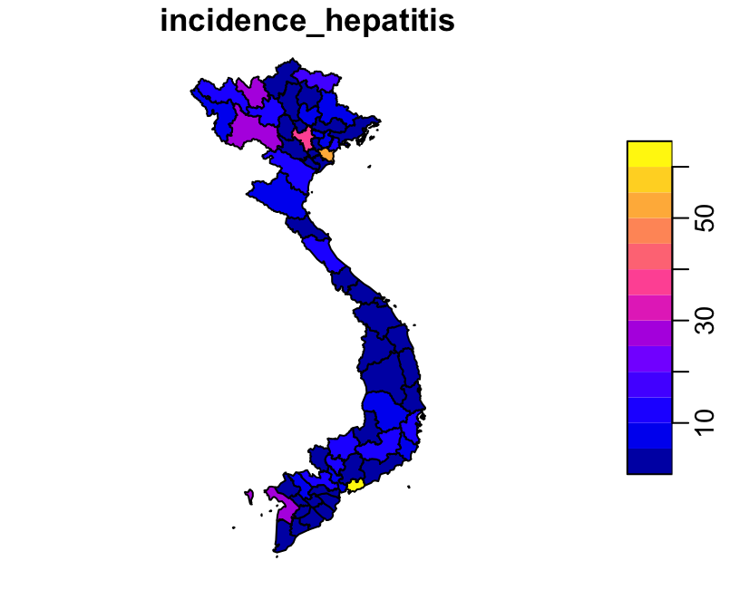

```r
> plot(hep_map["incidence_hepatitis"])
```

You can twickle the look of the map. I let you look at the help of the function for that or, even better, at the vignettes of the `sf` package. You can also aggregate the data of several provinces or plot by region (you’ll see that the regions information in available in the `vietnam` data frame). Let me know if there are things that you have difficulties doing.

## Population data

In addition to the `dplyr` package, here we’ll need the `purrr` package:

```r
> library(purrr)
```

Socio-demo-economic data from [GSO](https://www.gso.gov.vn/Default.aspx?tabid=217) are available in the following package:

```r
> library(gso)
```

There is a huge amount of data in this package and it may not be super easy to find what you are looking for. To make it easier, load the `content` data frame:

```r
> data(content)
```

`content` is a big data frame of the metadata of the data:

```r
> content
# A tibble: 335 x 8
   category                  subcategory data_frame                    data_name  time_resolution  time_range sp_resolution data
   <chr>                     <chr>       <chr>                         <chr>      <chr>            <chr>      <chr>         <named list>
 1 Administrative Unit, Lan… Sea level   Average of sea level at some… sea_level… month            2014-2016  station       <df[,4] [576…
 2 Administrative Unit, Lan… Sea level   Average of sea level at some… sea_level… year             2013-2016  station       <df[,3] [64 …
 3 Administrative Unit, Lan… Climate     Change in average precipitat… climate_1  year             2010-2016  station       <df[,9] [35 …
 4 Administrative Unit, Lan… Land use    Land use (As of 31 Februarry… land_use_1 single time poi… 28-02-2015 country       <df[,96] [1 …
 5 Administrative Unit, Lan… Land use    Land use by province (As of … land_use_2 single time poi… 31-12-2015 province      <df[,6] [63 …
 6 Administrative Unit, Lan… Climate     Mean air temperature at some… climate_2  year             2006-2016  station       <df[,3] [154…
 7 Administrative Unit, Lan… Climate     Mean humidity at some statio… climate_3  year             2006-2016  station       <df[,3] [165…
 8 Administrative Unit, Lan… Climate     Monthly mean air temperature… climate_4  month            2002-2016  station       <df[,4] [2,7…
 9 Administrative Unit, Lan… Climate     Monthly mean humidity at som… climate_5  month            2002-2016  station       <df[,4] [2,7…
10 Administrative Unit, Lan… Climate     Monthly rainfall at some sta… climate_6  month            2002-2016  station       <df[,4] [2,7…
# … with 325 more rows
```

You can see in particular that data sets are organised by category, which makes the search a bit easier. You can list the different categories as so:

```r
> unique(content$category)
 [1] "Administrative Unit, Land and Climate"             "Agriculture, Forestry and Fishery"
 [3] "Education"                                         "Health, Culture and Living Standard"
 [5] "Industry"                                          "International Statistics"
 [7] "Investment and Construction"                       "National Accounts"
 [9] "Population and Employment"                         "Trade, Price and Tourism"
[11] "Transport, Postal Services and Telecommunications" NA
```

If you are interested in population sizes, it’s likely that what you are looking for is in the `Population and Employment` category. You can also filter by subcategory and spatial resolution

```r
> content %>%
+   filter(category == "Population and Employment", subcategory == "Demography", sp_resolution == "province")
# A tibble: 12 x 8
   category         subcategory data_frame                               data_name   time_resolution time_range sp_resolution data
   <chr>            <chr>       <chr>                                    <chr>       <chr>           <chr>      <chr>         <list>
 1 Population and … Demography  Area, population and population density… demography… year            2011-2016  province      <df[,5] [3…
 2 Population and … Demography  Average age of first marriage by provin… demography… year            2010-2016  province      <df[,3] [3…
 3 Population and … Demography  Average population by sex by residence … demography… year            1995-2016  province      <df[,7] [1…
 4 Population and … Demography  Crude birth rate, crude death rate and … demography… year            2005-2016  province      <df[,5] [7…
 5 Population and … Demography  In-migration rate, out-migration rate a… demography… year            2005-2016  province      <df[,5] [7…
 6 Population and … Demography  Infant mortality rate by province        demography… year            2005-2016  province      <df[,3] [7…
 7 Population and … Demography  Number of divorce cases cleared up by p… demography… year            2013-2016  province      <df[,5] [2…
 8 Population and … Demography  Percentage of literate population at 15… demography… year            2006-2016  province      <df[,3] [5…
 9 Population and … Demography  Population growth rate by province       demography… year            2005-2016  province      <df[,3] [7…
10 Population and … Demography  Sex ratio of population by province      demography… year            2005-2016  province      <df[,3] [7…
11 Population and … Demography  Total fertility rate by province         demography… year            2005-2016  province      <df[,3] [7…
12 Population and … Demography  Under five mortality rate by province    demography… year            2010-2016  province      <df[,3] [3…
```

It seems that the first or the third data sets could be useful for you, i.e. `demography_1` and `demography_5` here. To retrieve the data sets:

```r
> demo1 <- content %>%
+   filter(data_name == "demography_1") %>%
+   pluck("data") %>%
+   first() %>%
+   transmute(year     = year,
+             province = province,
+             popsize  = 1000 * average_population_thous_pers)
```

which gives:

```r
> head(demo1)
  year          province popsize
1 2011          An Giang 2149000
2 2011 Ba Ria - Vung Tau 1022500
3 2011         Bac Giang 1581800
4 2011           Bac Kan  300400
5 2011          Bac Lieu  864900
6 2011          Bac Ninh 1063400
```

and

```r
> demo5 <- content %>%
+   filter(data_name == "demography_5") %>%
+   pluck("data") %>%
+   first() %>%
+   transmute(year     = year,
+             province = province,
+             popsize  = 1000 * total)
```

which gives:

```r
> head(demo5)
  year          province popsize
1 1995          An Giang 1970100
2 1995 Ba Ria - Vung Tau  708900
3 1995         Bac Giang 1431000
4 1995           Bac Kan  254200
5 1995          Bac Lieu  709500
6 1995          Bac Ninh  916000
```

Note that the time range of the 2 data sets are not the same:

```r
> range(demo1$year)
[1] 2011 2016
```

and

```r
> range(demo5$year)
[1] 1995 2016
```

If you are interested in the population sizes in 2011:

```r
> demo1_2011 <- demo1 %>%
+   filter(year == 2011) %>%
+   select(-year) %>%
+   arrange(province)
```

and

```r
> demo5_2011 <- demo5 %>%
+   filter(year == 2011) %>%
+   select(-year) %>%
+   na.exclude() %>% # removing Ha Tay
+   arrange(province)
```

You can verify that the 2 data sets are actually identical:

```r
> all(unlist(map2(demo1_2011, demo5_2011, identical)))
[1] TRUE
```

You can also check the total population size:

```r
> sum(demo1_2011$popsize)
[1] 87859700
```

Same as before, the province names in the `gso` package are compatible with those in the `gdpm` and the `gadmVN` packages, which makes it easy for you to map the data:

```r
> pop_map <- left_join(vietnam, demo1_2011, by = "province")
```

and:

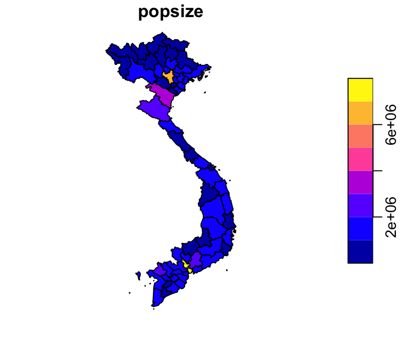

```r
> plot(pop_map["popsize"])
```

or to calculate incidence rates, per 100,000 for example:

```r
> incidence_rate_map <- vietnam %>%
+   left_join(hep, by = "province") %>%
+   left_join(demo1_2011, by = "province") %>%
+   mutate(incidence_rate = 1e5 * incidence_hepatitis / popsize)
```

and plot it:

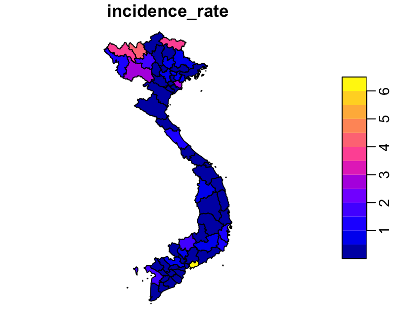

```r
> plot(incidence_rate_map["incidence_rate"])
```